# Practica Arboles Decision

Lucas Poveda

2023-12-11

Utiliza los datos de cáncer de mama que hemos trabajado en clase “breast_train_prep” y “breast_test_prep” (que puedes encontrar en el fichero “breast.Rdata” del Moodle) para crear un modelo predictivo usando CART y Bagged Trees. Compara los resultados con los obtenidos mediant KNN y LDA reportados en el bookdown del curso.

```r
library(tidyverse)
library(caret)
```

```r
library(rpart)
library(rpart.plot)
```

ARREGLO PARA QUE EL CODIGO DEL BOOKDOWN FUNCIONE

```r
#setwd("C:/Users/lucas/Desktop/Universidad/4o/AA1")
load("breast.Rdata")
breast <- load("breast.Rdata")
new_names <- c("concave points_se","concave points_worst")
names(breast_train_prep)[names(breast_train_prep) %in% new_names] <- c("concave_points_se","concave_points_worst")
names(breast_test_prep)[names(breast_test_prep) %in% new_names] <- c("concave_points_se","concave_points_worst")
```

**CART**

```r
skimr::skim(breast_train_prep)
```

Data summary

| Name | breast_train_prep |
| --- | --- |
| Number of rows | 399 |
| Number of columns | 20 |
| _______________________ |  |
| Column type frequency: |  |
| factor | 1 |
| numeric | 19 |
| ________________________ |  |
| Group variables | None |

**Variable type: factor**

| skim_variable | n_missing | complete_rate | ordered | n_unique | top_counts |
| --- | --- | --- | --- | --- | --- |
| diagnosis | 0 | 1 | FALSE | 2 | B: 250, M: 149 |

**Variable type: numeric**

| skim_variable | n_missing | complete_rate | mean | sd | p0 | p25 | p50 | p75 | p100 | hist |
| --- | --- | --- | --- | --- | --- | --- | --- | --- | --- | --- |
| texture_mean | 0 | 1 | 0 | 1 | -2.02 | -0.72 | -0.12 | 0.63 | 4.80 | ▅▇▃▁▁ |
| area_mean | 0 | 1 | 0 | 1 | -1.46 | -0.68 | -0.29 | 0.39 | 5.28 | ▇▃▂▁▁ |
| smoothness_mean | 0 | 1 | 0 | 1 | -2.23 | -0.70 | -0.01 | 0.58 | 4.54 | ▃▇▃▁▁ |
| compactness_mean | 0 | 1 | 0 | 1 | -1.47 | -0.77 | -0.23 | 0.49 | 4.55 | ▇▆▂▁▁ |
| symmetry_mean | 0 | 1 | 0 | 1 | -2.68 | -0.69 | -0.07 | 0.53 | 4.38 | ▁▇▆▁▁ |
| fractal_dimension_mean | 0 | 1 | 0 | 1 | -1.81 | -0.69 | -0.16 | 0.50 | 4.99 | ▆▇▂▁▁ |
| texture_se | 0 | 1 | 0 | 1 | -1.65 | -0.71 | -0.23 | 0.51 | 5.32 | ▇▆▂▁▁ |
| area_se | 0 | 1 | 0 | 1 | -0.78 | -0.51 | -0.36 | 0.17 | 11.70 | ▇▁▁▁▁ |
| smoothness_se | 0 | 1 | 0 | 1 | -1.42 | -0.60 | -0.21 | 0.35 | 7.74 | ▇▂▁▁▁ |
| compactness_se | 0 | 1 | 0 | 1 | -1.28 | -0.70 | -0.27 | 0.40 | 6.33 | ▇▃▁▁▁ |
| concavity_se | 0 | 1 | 0 | 1 | -1.29 | -0.68 | -0.21 | 0.40 | 5.10 | ▇▅▁▁▁ |
| concave_points_se | 0 | 1 | 0 | 1 | -2.10 | -0.69 | -0.12 | 0.55 | 5.02 | ▃▇▂▁▁ |
| symmetry_se | 0 | 1 | 0 | 1 | -1.51 | -0.65 | -0.21 | 0.32 | 6.99 | ▇▃▁▁▁ |
| fractal_dimension_se | 0 | 1 | 0 | 1 | -1.33 | -0.68 | -0.19 | 0.40 | 6.63 | ▇▃▁▁▁ |
| smoothness_worst | 0 | 1 | 0 | 1 | -2.07 | -0.70 | -0.06 | 0.61 | 3.79 | ▃▇▆▁▁ |
| compactness_worst | 0 | 1 | 0 | 1 | -1.31 | -0.69 | -0.27 | 0.52 | 4.97 | ▇▅▁▁▁ |
| concave_points_worst | 0 | 1 | 0 | 1 | -1.73 | -0.77 | -0.25 | 0.74 | 2.69 | ▅▇▅▃▁ |
| symmetry_worst | 0 | 1 | 0 | 1 | -2.06 | -0.62 | -0.14 | 0.45 | 5.76 | ▅▇▁▁▁ |
| fractal_dimension_worst | 0 | 1 | 0 | 1 | -1.59 | -0.67 | -0.23 | 0.42 | 6.70 | ▇▃▁▁▁ |

Creamos el modelo con el arbol completo, que luego podaremos:

```r
model_full<-rpart(formula = diagnosis~., data=breast_train_prep, method="class"); model_full
```

```
## n= 399
##
## node), split, n, loss, yval, (yprob)
##       * denotes terminal node
##
##  1) root 399 149 B (0.626566416 0.373433584)
##    2) concave_points_worst< 0.5018401 273  27 B (0.901098901 0.098901099)
##      4) area_mean< 0.1163047 249   9 B (0.963855422 0.036144578)
##        8) concave_points_worst< -0.05205819 217   1 B (0.995391705 0.004608295) *
##        9) concave_points_worst>=-0.05205819 32   8 B (0.750000000 0.250000000)
##         18) texture_mean< 0.4492966 21   1 B (0.952380952 0.047619048) *
##         19) texture_mean>=0.4492966 11   4 M (0.363636364 0.636363636) *
##      5) area_mean>=0.1163047 24   6 M (0.250000000 0.750000000) *
##    3) concave_points_worst>=0.5018401 126   4 M (0.031746032 0.968253968) *
```

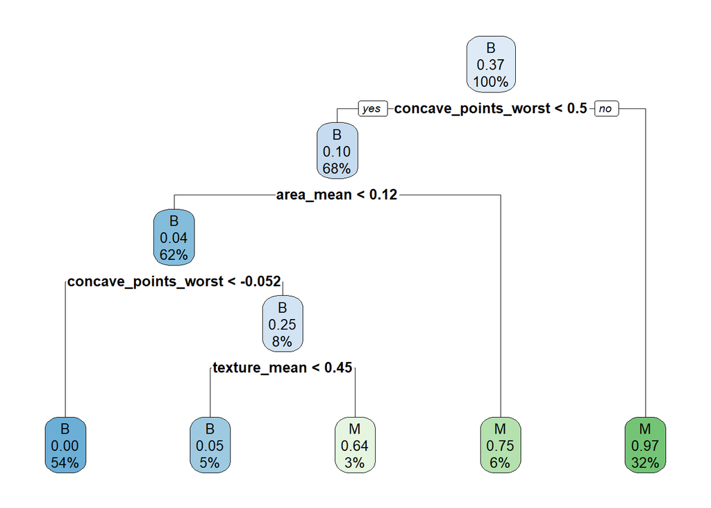

```r
rpart.plot(model_full, yesno=TRUE)
```

Usamos la siguiente tabla para decidir cómo podar el arbol:

```r
printcp(model_full)
```

```
##
## Classification tree:
## rpart(formula = diagnosis ~ ., data = breast_train_prep, method = "class")
##
## Variables actually used in tree construction:
## [1] area_mean            concave_points_worst texture_mean
##
## Root node error: 149/399 = 0.37343
##
## n= 399
##
##         CP nsplit rel error  xerror     xstd
## 1 0.791946      0   1.00000 1.00000 0.064847
## 2 0.080537      1   0.20805 0.24832 0.038885
## 3 0.010067      2   0.12752 0.18121 0.033673
## 4 0.010000      4   0.10738 0.22819 0.037429
```

Podaremos el arbol para el modelo que tiene un error de CV relativo más pequeño (menor xerror), es decir, nos quedamos con cp=0.010067

```r
model_full_cart<-rpart(
  formula=diagnosis~.,
  data=breast_train_prep,
  method="class",
  cp=0.010067
)
print(model_full_cart)
```

```
## n= 399
##
## node), split, n, loss, yval, (yprob)
##       * denotes terminal node
##
##  1) root 399 149 B (0.626566416 0.373433584)
##    2) concave_points_worst< 0.5018401 273  27 B (0.901098901 0.098901099)
##      4) area_mean< 0.1163047 249   9 B (0.963855422 0.036144578)
##        8) concave_points_worst< -0.05205819 217   1 B (0.995391705 0.004608295) *
##        9) concave_points_worst>=-0.05205819 32   8 B (0.750000000 0.250000000)
##         18) texture_mean< 0.4492966 21   1 B (0.952380952 0.047619048) *
##         19) texture_mean>=0.4492966 11   4 M (0.363636364 0.636363636) *
##      5) area_mean>=0.1163047 24   6 M (0.250000000 0.750000000) *
##    3) concave_points_worst>=0.5018401 126   4 M (0.031746032 0.968253968) *
```

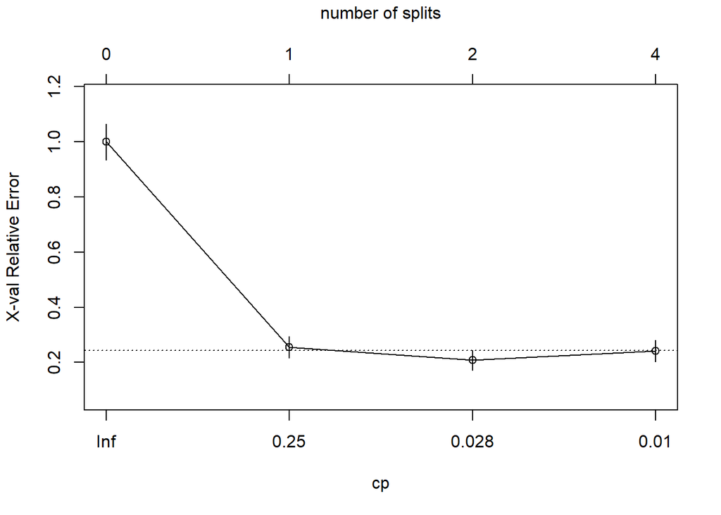

```r
plotcp(model_full_cart, upper="splits")
```

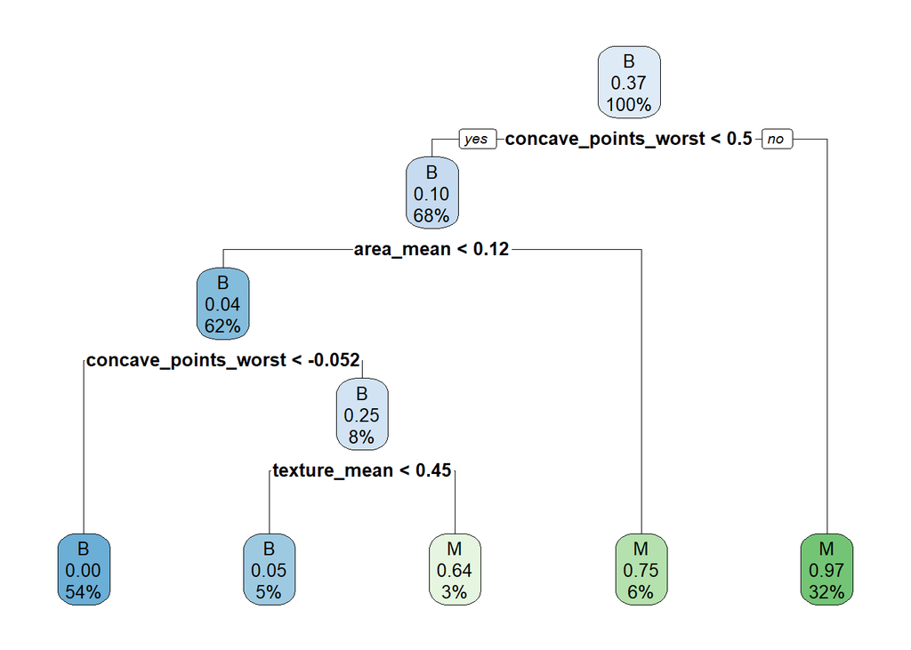

```r
mdl_cart<-prune(model_full_cart, cp=model_full_cart$cptable[model_full_cart$cptable[,2]==3, "CP"])
rpart.plot(mdl_cart,yesno=TRUE)
```

Miramos la importancia de cada variable para este modelo

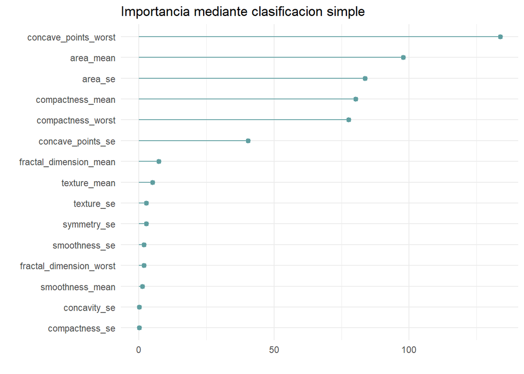

```r
mdl_cart$variable.importance%>%
  data.frame()%>%
  rownames_to_column(var="Feature")%>%
  rename(Overall='.')%>%
  ggplot(aes(x=fct_reorder(Feature, Overall), y=Overall))+geom_pointrange(aes(ymin=0, ymax=Overall), color="cadetblue", size=.3)+theme_minimal()+coord_flip()+labs(x="",y="",title="Importancia mediante clasificacion simple")
```

```r
summary(mdl_cart)
```

```
## Call:
## rpart(formula = diagnosis ~ ., data = breast_train_prep, method = "class",
##     cp = 0.010067)
##   n= 399
##
##           CP nsplit rel error    xerror       xstd
## 1 0.79194631      0 1.0000000 1.0000000 0.06484708
## 2 0.08053691      1 0.2080537 0.2550336 0.03935253
## 3 0.01006711      2 0.1275168 0.2080537 0.03588658
## 4 0.01006700      4 0.1073826 0.2416107 0.03840890
##
## Variable importance
##   concave_points_worst              area_mean                area_se
##                     25                     18                     16
##       compactness_mean      compactness_worst      concave_points_se
##                     15                     14                      8
## fractal_dimension_mean           texture_mean            symmetry_se
##                      1                      1                      1
##             texture_se
##                      1
##
## Node number 1: 399 observations,    complexity param=0.7919463
##   predicted class=B  expected loss=0.3734336  P(node) =1
##     class counts:   250   149
##    probabilities: 0.627 0.373
##   left son=2 (273 obs) right son=3 (126 obs)
##   Primary splits:
##       concave_points_worst < 0.5018401   to the left,  improve=130.31140, (0 missing)
##       area_mean            < 0.1163047   to the left,  improve=112.57900, (0 missing)
##       area_se              < -0.1906208  to the left,  improve= 99.61102, (0 missing)
##       compactness_mean     < -0.04067293 to the left,  improve= 71.43953, (0 missing)
##       compactness_worst    < 0.07119025  to the left,  improve= 67.80976, (0 missing)
##   Surrogate splits:
##       compactness_mean  < 0.3535798   to the left,  agree=0.872, adj=0.595, (0 split)
##       area_mean         < 0.1684214   to the left,  agree=0.867, adj=0.579, (0 split)
##       compactness_worst < 0.340124    to the left,  agree=0.867, adj=0.579, (0 split)
##       area_se           < 0.232342    to the left,  agree=0.862, adj=0.563, (0 split)
##       concave_points_se < 0.05885068  to the left,  agree=0.782, adj=0.310, (0 split)
##
## Node number 2: 273 observations,    complexity param=0.08053691
```

[output cut: 62 more lines]

```
##       compactness_mean        < -0.07585385 to the right, agree=0.812, adj=0.455, (0 split)
##       fractal_dimension_mean  < -0.7980455  to the right, agree=0.781, adj=0.364, (0 split)
##       compactness_worst       < -0.2543774  to the right, agree=0.781, adj=0.364, (0 split)
##       fractal_dimension_worst < -0.666157   to the right, agree=0.781, adj=0.364, (0 split)
##       smoothness_mean         < -0.1325389  to the right, agree=0.750, adj=0.273, (0 split)
##
## Node number 18: 21 observations
##   predicted class=B  expected loss=0.04761905  P(node) =0.05263158
##     class counts:    20     1
##    probabilities: 0.952 0.048
##
## Node number 19: 11 observations
##   predicted class=M  expected loss=0.3636364  P(node) =0.02756892
##     class counts:     4     7
##    probabilities: 0.364 0.636
```

*Evaluamos el modelo en la muestra test*

```r
pred<-predict(mdl_cart, newdata = breast_test_prep, type="class")
cm_mdlcart<-confusionMatrix(pred, breast_test_prep$diagnosis)
cm_mdlcart
```

```
## Confusion Matrix and Statistics
##
##           Reference
## Prediction  B  M
##          B 95  3
##          M 12 60
##
##                Accuracy : 0.9118
##                  95% CI : (0.8586, 0.9498)
##     No Information Rate : 0.6294
##     P-Value [Acc > NIR] : < 2e-16
##
##                   Kappa : 0.8163
##
##  Mcnemar's Test P-Value : 0.03887
##
##             Sensitivity : 0.8879
##             Specificity : 0.9524
##          Pos Pred Value : 0.9694
##          Neg Pred Value : 0.8333
##              Prevalence : 0.6294
##          Detection Rate : 0.5588
##    Detection Prevalence : 0.5765
##       Balanced Accuracy : 0.9201
##
##        'Positive' Class : B
##
```

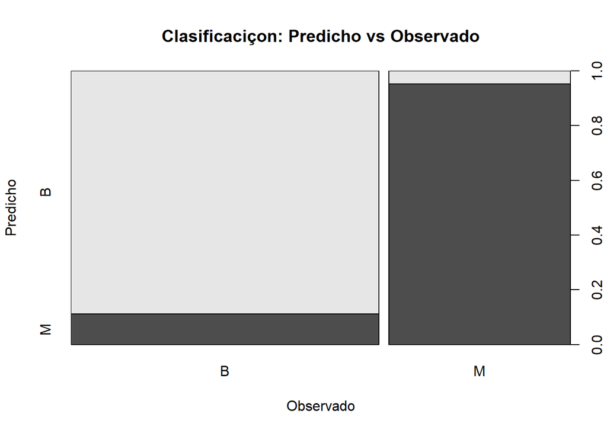

```r
plot(breast_test_prep$diagnosis, pred, main="Clasificaciçon: Predicho vs Observado", xlab="Observado", ylab="Predicho")
```

**Arboles de Regressión**

Primero construimos un arbol completo y luego usamos validaciçon cruzada para podarlo

```r
model_cart_full<-rpart(diagnosis~., breast_train_prep, method="anova");model_cart_full
```

```
## n= 399
##
## node), split, n, deviance, yval
##       * denotes terminal node
##
##  1) root 399 93.3584000 1.373434
##    2) concave_points_worst< 0.5018401 273 24.3296700 1.098901
##      4) area_mean< 0.1163047 249  8.6746990 1.036145
##        8) concave_points_worst< -0.05205819 217  0.9953917 1.004608 *
##        9) concave_points_worst>=-0.05205819 32  6.0000000 1.250000
##         18) texture_mean< 0.4492966 21  0.9523810 1.047619 *
##         19) texture_mean>=0.4492966 11  2.5454550 1.636364 *
##      5) area_mean>=0.1163047 24  4.5000000 1.750000
##       10) texture_mean< 0.0924265 11  2.7272730 1.454545 *
##       11) texture_mean>=0.0924265 13  0.0000000 2.000000 *
##    3) concave_points_worst>=0.5018401 126  3.8730160 1.968254
##      6) area_se< -0.415271 7  1.7142860 1.571429 *
##      7) area_se>=-0.415271 119  0.9915966 1.991597 *
```

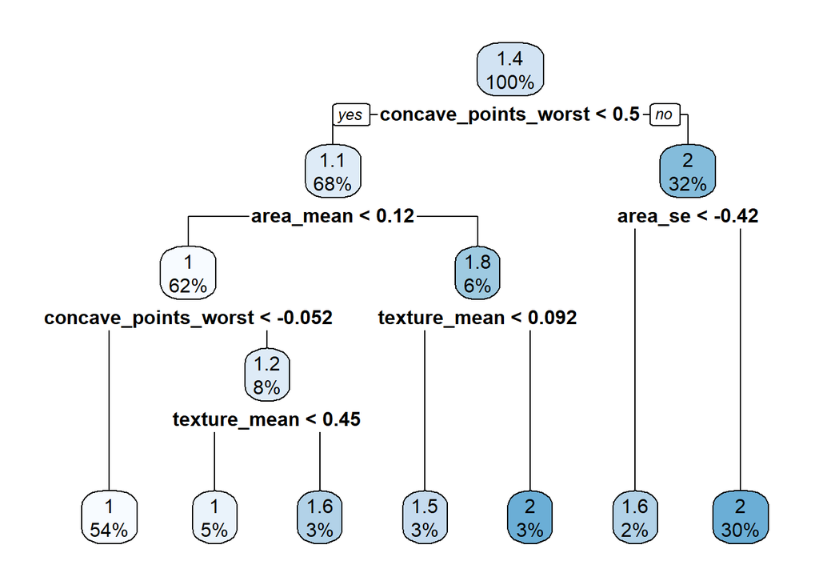

```r
rpart.plot(model_cart_full, yesno=TRUE)
```

Buscamos el cp óptimo:

```r
printcp(model_cart_full)
```

```
##
## Regression tree:
## rpart(formula = diagnosis ~ ., data = breast_train_prep, method = "anova")
##
## Variables actually used in tree construction:
## [1] area_mean            area_se              concave_points_worst
## [4] texture_mean
##
## Root node error: 93.358/399 = 0.23398
##
## n= 399
##
##         CP nsplit rel error  xerror     xstd
## 1 0.697909      0   1.00000 1.00457 0.026351
## 2 0.119485      1   0.30209 0.35938 0.052167
## 3 0.022395      2   0.18261 0.24685 0.044622
## 4 0.018988      4   0.13782 0.24430 0.043995
## 5 0.012502      5   0.11883 0.23547 0.043278
## 6 0.010000      6   0.10633 0.21625 0.040545
```

Para encontrar el arbol con menor error error de predicción elejimos el que tiene SSE relativo más bajo (xerror), es decir, nos quedamos con cp=0.01

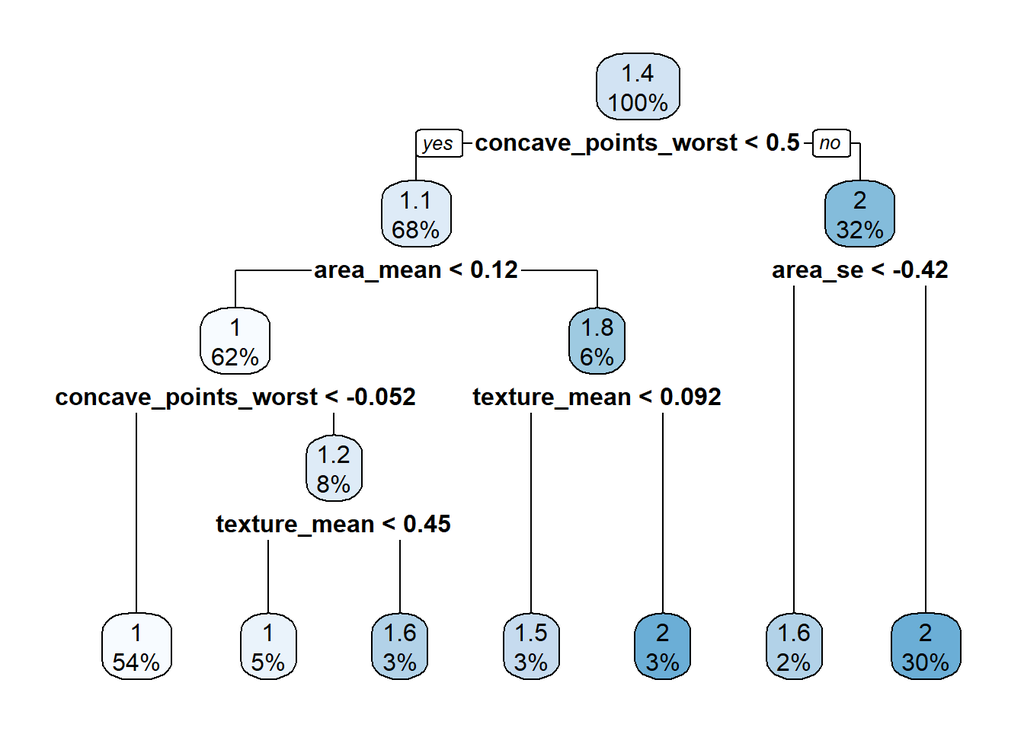

```r
mdl_cart2<-prune(model_cart_full, cp=model_cart_full$cptable[model_cart_full$cptable[,2]==6,"CP"])
rpart.plot(mdl_cart2,yesno=TRUE)
```

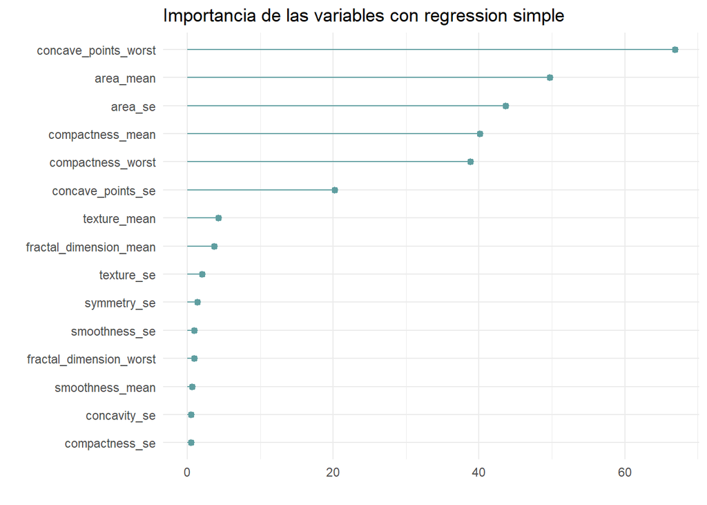

```r
mdl_cart2$variable.importance%>%
  data.frame()%>%
  rownames_to_column(var="diagnosis")%>%
  rename(Overall='.')%>%
  ggplot(aes(x=fct_reorder(diagnosis, Overall),y=Overall))+
  geom_pointrange(aes(ymin=0,ymax=Overall),color="cadetblue",size=.3)+
  theme_minimal()+
  coord_flip()+
  labs(x="",y="",title="Importancia de las variables con regression simple")
```

Predicción:

```r
pred2<-predict(mdl_cart2, newdata = breast_test_prep, type="vector")
#cm_mdlcart2<-confusionMatrix(pred2, breast_test_prep$diagnosis)
#cm_mdlcart2
```

No he podido realizar esta predicción porque no encuentro dondte tengo el error. Se que me he equivocado porque el modelo deberia predecir el factor diagnosis, pero las predicciónes son numericos, asique en algun lugar debe haber un error

**Bagged Tree**

Este es un metodo que combina varios arboles de decision para mejorar el rendimiento predictivo.

```r
Bagcontrol<-trainControl(
  method="cv",
  number=10,
  classProbs = TRUE,
  savePredictions="final"
)
```

```r
mdl_bag<-train(
  diagnosis~.,
  data=breast_train_prep,
  method="treebag",
  trControl=Bagcontrol,
  metric="ROC"
)
mdl_bag$finalModel
```

```
##
## Bagging classification trees with 25 bootstrap replications
```

Miramos como rinde en los datos test:

```r
pred_bag<-predict(mdl_bag,newdata=breast_test_prep,type="raw")
cm_bag<-confusionMatrix(pred_bag,breast_test_prep$diagnosis)
cm_bag
```

```
## Confusion Matrix and Statistics
##
##           Reference
## Prediction   B   M
##          B 102   3
##          M   5  60
##
##                Accuracy : 0.9529
##                  95% CI : (0.9094, 0.9795)
##     No Information Rate : 0.6294
##     P-Value [Acc > NIR] : <2e-16
##
##                   Kappa : 0.8998
##
##  Mcnemar's Test P-Value : 0.7237
##
##             Sensitivity : 0.9533
##             Specificity : 0.9524
##          Pos Pred Value : 0.9714
##          Neg Pred Value : 0.9231
##              Prevalence : 0.6294
##          Detection Rate : 0.6000
##    Detection Prevalence : 0.6176
##       Balanced Accuracy : 0.9528
##
##        'Positive' Class : B
##
```

La curva ROC

```r
#pred_bag2<-predict(mdl_bag,newdata=breast_test_prep,type="prob")
#roc.bag<-roc(breast_test_prep$diagnosis,pred_bag2,print.auc=TRUE,
          #   ci=TRUE,
          #   plot=TRUE)
```

El codigo da error porque no encuentra la metrica ROC en la funcion trainControl

Importancia de las variables:

```r
#plot(VarImp(mdl_bag),main="Importancia de las variables con Bagging")
```

La funcion VarImp no la encuentra

Comparacion entre metodos:

```r
#scoreboard<-data.frame(Modelo="Bagging",
                                        # Accurancy=cm_bag$overall["Accurancy"],
                                        # ROC=roc.bag$auc)%>%
 # arrange(desc(ROC))
#knit::kable(scoreboard,row.names=FALSE)
```

Como hemos tenido problemas con la metrica ROC, no podemos ejecutar esta parte del codigo

```r
mdl_bag3<-train(
  diagnosis~.,
  data=breast_train_prep,
  method="treebag",
  trControl=Bagcontrol
)
mdl_bag3
```

```
## Bagged CART
##
## 399 samples
##  19 predictor
##   2 classes: 'B', 'M'
##
## No pre-processing
## Resampling: Cross-Validated (10 fold)
## Summary of sample sizes: 359, 359, 359, 360, 359, 359, ...
## Resampling results:
##
##   Accuracy   Kappa
##   0.9448718  0.8813088
```

Miramos el rendimiento en los datos test:

```r
pred_bag3<-bind_cols(
  Predicted=predict(mdl_bag3,newdata=breast_test_prep),
  Actual=breast_test_prep$diagnosis
)

rmse_bag<-RMSE(pred=pred_bag3$Predicted, obs=pred_bag3$Actual)
```

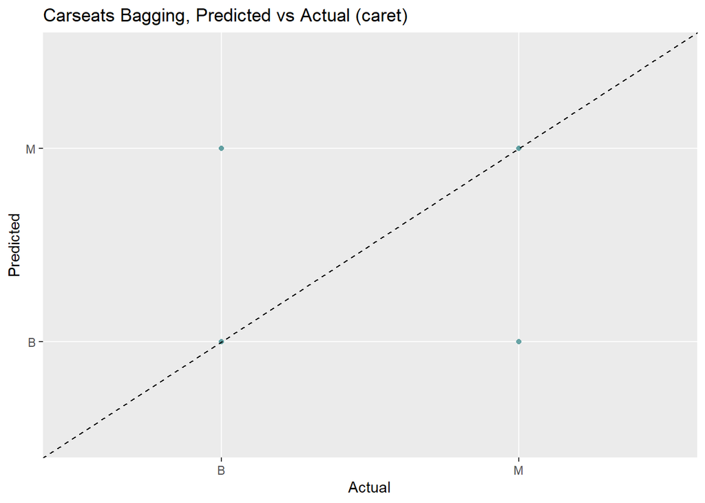

```r
pred_bag3%>%
  ggplot(aes(x=Actual, y=Predicted))+
  geom_point(alpha=0.6, color="cadetblue")+
  geom_smooth(method="loess", formula="y-x")+
  geom_abline(intercept=0, slope=1, linetype=2)+
  labs(title="Carseats Bagging, Predicted vs Actual (caret)")
```

La importancia de las variables son:

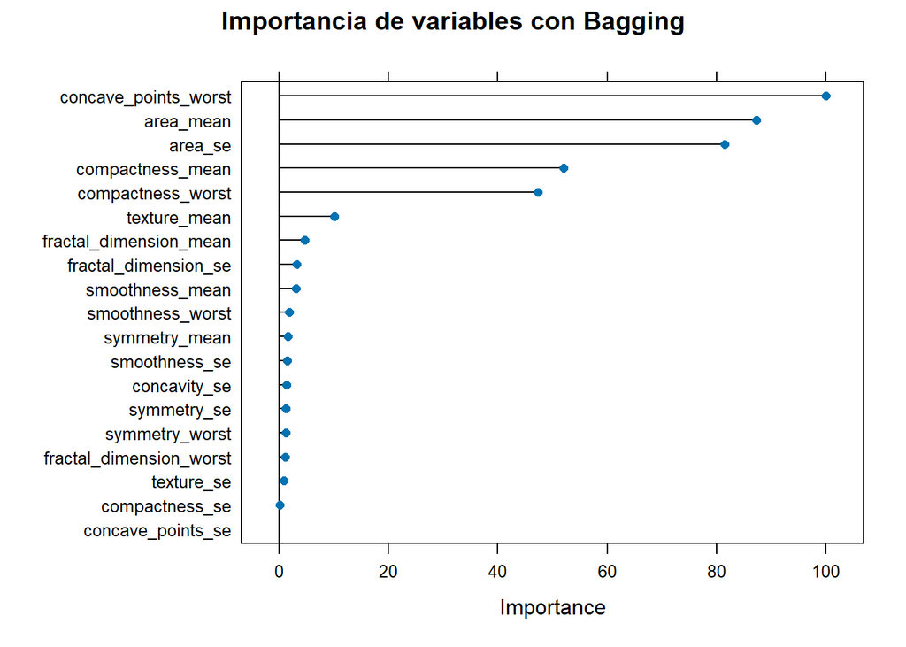

```r
plot(varImp(mdl_bag3),main="Importancia de variables con Bagging")
```

Comparando:

```r
scoreboard2<-data.frame(Modelo="Bagging",RMSE=rmse_bag)%>%arrange(RMSE)
                   knitr::kable(scoreboard2,row.names=FALSE)
```

| Modelo | RMSE |
| --- | --- |
| Bagging | NA |

Ahora quedaria comparar estos modelos con los de LDA y KNN, pero no puedo hacerlo ya que el codigo no se ejecuta